# Reproducible Data - Course Project 1

**1. Load and preprocess the data**

```r
steps_df <- read.csv("activity.csv", na.strings="NA", stringsAsFactors=FALSE)
```

Note: this file did not require any other preprocessing before proceeding.

**2. What is the mean total number of steps taken per day?**

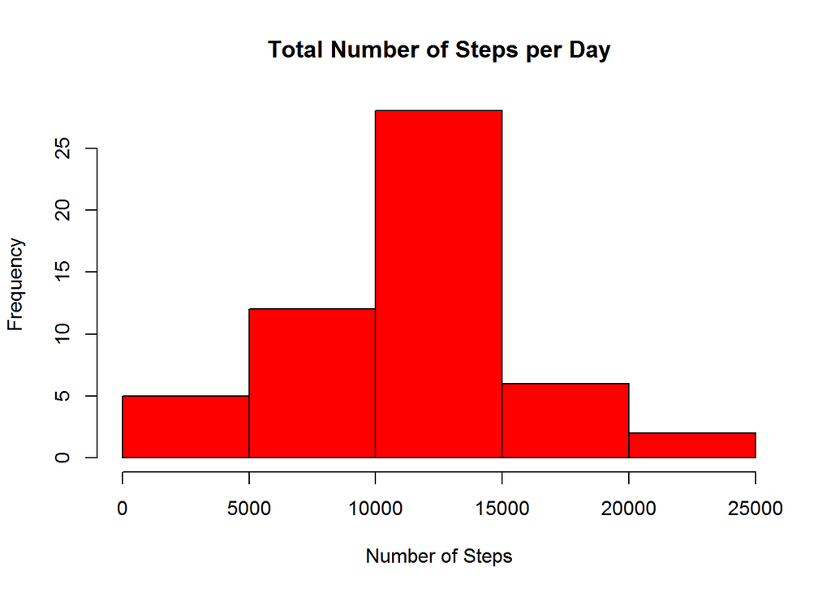

```r
#Calculate the total steps per day and create a histogram of the results:

#get total number of steps per day
day_steps <- aggregate(steps ~ date, data = steps_df, FUN = sum)

#histogram it
hist(day_steps$steps, main = "Total Number of Steps per Day",
     xlab = "Number of Steps", col = "red")
```

The mean number of total steps per day is 10766 steps, while the median is 10765 per day.

**3. What is the average daily activity pattern?**

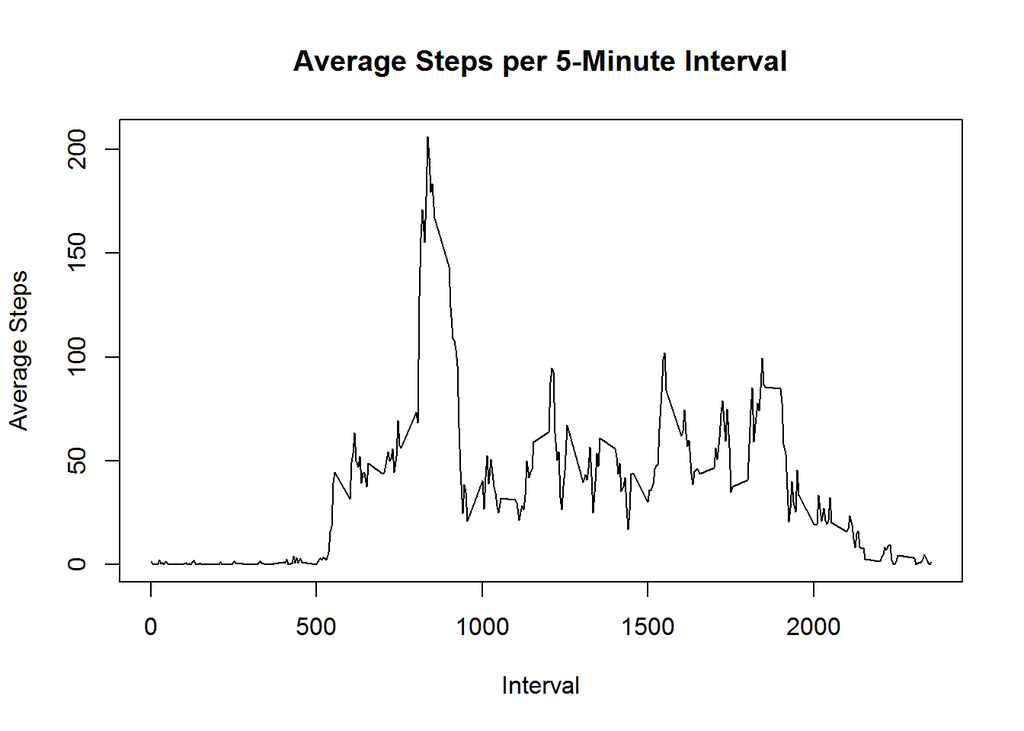

```r
#Make a time series plot of the interval and avg steps across all days:

#get avg steps taken per interval
int_steps <- aggregate(steps ~ interval, data = steps_df, FUN = mean)

#plot the data
plot(int_steps, type="l", xlab = "Interval", ylab = "Average Steps",
     main = "Average Steps per 5-Minute Interval" )
```

On average, the 835th 5-minute interval contains the maximum number of steps.

**4. Imputing missing values**

There are 2304 missing values in this dataset. I will fill the missing values with the mean number of steps across all days for the particular interval.

```r
#Create a new data set with missing values filled in:

imp_steps <- steps_df

for(r in 1:nrow(imp_steps)){
    if (is.na(imp_steps$steps[r])) {
        repl <- int_steps$steps[int_steps$interval == imp_steps$interval[r]];
        imp_steps$steps[r] <- repl;
    }
}
```

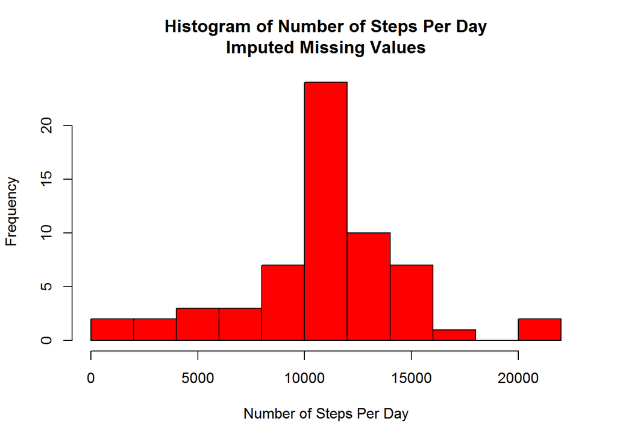

```r
#Make a histogram of total steps per day with missing values filled in:

#get # of steps per day
day_steps <- with(imp_steps, tapply(steps, date, sum, na.rm=TRUE))

#histogram it
hist(day_steps, main = "Histogram of Number of Steps Per Day\nImputed Missing Values",
     xlab = "Number of Steps Per Day", col = "red", breaks=15)
```

**5. Are there differences in activity patterns between weekdays and weekends?**

```r
#Create a new factor variable in the dataset indicating if the day is a weekend or weekday:

#convert date field to Date datatype
imp_steps$date2 <- as.Date(imp_steps$date, format = "%Y-%m-%d")

#get day of week for each date
imp_steps$day <- weekdays(imp_steps$date2)

#set new column indicating if the day is a weekend or weekday
for (i in 1:nrow(imp_steps)) {
    if(imp_steps$day[i] == "Saturday" | imp_steps$day[i] == "Sunday") {
        imp_steps$day_type[i] <- "Weekend"
    } else {
        imp_steps$day_type[i] <- "Weekday"
    }
}

#convert to a factor for later
imp_steps$day_type <- factor(imp_steps$day_type)
```

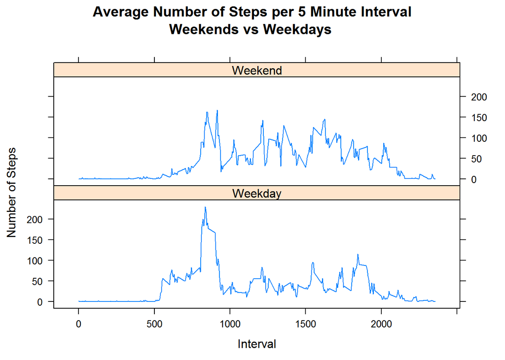

```r
#Make a time series plot of the average steps for each interval, divided out by weekend/weekday:

day_type_steps <- aggregate(steps ~ interval + day_type, data = imp_steps, FUN = mean)

library("lattice")

xyplot(steps ~ interval | day_type, day_type_steps, type = "l", layout = c(1, 2),
       xlab = "Interval", ylab = "Number of Steps",
       main = "Average Number of Steps per 5 Minute Interval\nWeekends vs Weekdays ")
```